# A1_Tessmann_Meag

# Code Chunk 6: Data Prep

A. Partition the imported data set for a simple hold-out evaluation: 70% for training and the other 30% for testing. Show the summary of training and test sets. B. Show the proportions of “LEAVE” and “STAY” of the target variable in the training set and in the test set, separately.

```r
#get number of observations
n_obs <- nrow(churn)

#create test, training sets
set.seed(123)
train_sample <- sample(n_obs, (n_obs*.7))
train <- churn[train_sample,]
test <- churn[-train_sample,]

#check test, training sets
summary(train)
```

```
##  COLLEGE         INCOME          OVERAGE          LEFTOVER        HOUSE
##  one :7026   Min.   : 20007   Min.   :  0.00   Min.   : 0.0   Min.   :150002
##  zero:6974   1st Qu.: 42430   1st Qu.:  0.00   1st Qu.: 0.0   1st Qu.:263542
##              Median : 75669   Median : 59.00   Median :14.0   Median :452725
##              Mean   : 80381   Mean   : 85.88   Mean   :23.9   Mean   :494106
##              3rd Qu.:115782   3rd Qu.:179.00   3rd Qu.:41.0   3rd Qu.:704738
##              Max.   :159954   Max.   :335.00   Max.   :89.0   Max.   :999989
##  HANDSET_PRICE   OVER_15MINS_CALLS_PER_MONTH AVERAGE_CALL_DURATION
##  Min.   :130.0   Min.   : 0.000              Min.   : 1.000
##  1st Qu.:219.0   1st Qu.: 1.000              1st Qu.: 2.000
##  Median :327.0   Median : 4.000              Median : 5.000
##  Mean   :390.2   Mean   : 7.972              Mean   : 5.995
##  3rd Qu.:535.0   3rd Qu.:15.000              3rd Qu.:10.000
##  Max.   :899.0   Max.   :29.000              Max.   :15.000
##  REPORTED_SATISFACTION  REPORTED_USAGE_LEVEL
##  avg       :1420       avg        : 689
##  sat       : 731       high       :1390
##  unsat     :2788       little     :5574
##  very_sat  :3516       very_high  :3541
##  very_unsat:5545       very_little:2806
##
##             CONSIDERING_CHANGE_OF_PLAN   LEAVE
##  actively_looking_into_it:3491         LEAVE:6867
##  considering             :5542         STAY :7133
##  never_thought           :1414
##  no                      :2829
##  perhaps                 : 724
##
```

```r
summary(test)
```

```
##  COLLEGE         INCOME          OVERAGE         LEFTOVER         HOUSE
##  one :3022   Min.   : 20031   Min.   : -2.0   Min.   : 0.00   Min.   :150125
##  zero:2978   1st Qu.: 41621   1st Qu.:  0.0   1st Qu.: 0.00   1st Qu.:264197
##              Median : 74596   Median : 60.0   Median :15.00   Median :450285
##              Mean   : 80049   Mean   : 86.2   Mean   :23.89   Mean   :490938
##              3rd Qu.:116007   3rd Qu.:179.0   3rd Qu.:41.00   3rd Qu.:697536
##              Max.   :159983   Max.   :290.0   Max.   :89.00   Max.   :999996
##  HANDSET_PRICE   OVER_15MINS_CALLS_PER_MONTH AVERAGE_CALL_DURATION
##  Min.   :130.0   Min.   : 0.000              Min.   : 1.00
##  1st Qu.:220.0   1st Qu.: 1.000              1st Qu.: 2.00
##  Median :324.0   Median : 4.000              Median : 5.00
##  Mean   :388.2   Mean   : 8.068              Mean   : 6.02
##  3rd Qu.:531.0   3rd Qu.:15.000              3rd Qu.:10.00
##  Max.   :899.0   Max.   :29.000              Max.   :15.00
##  REPORTED_SATISFACTION  REPORTED_USAGE_LEVEL
##  avg       : 602       avg        : 306
##  sat       : 294       high       : 610
##  unsat     :1203       little     :2301
##  very_sat  :1537       very_high  :1568
##  very_unsat:2364       very_little:1215
##
##             CONSIDERING_CHANGE_OF_PLAN   LEAVE
##  actively_looking_into_it:1503         LEAVE:2985
##  considering             :2378         STAY :3015
##  never_thought           : 581
##  no                      :1209
##  perhaps                 : 329
##
```

```r
# check for target variable distribution
prop.table(table(train$LEAVE))
```

```
##
##  LEAVE   STAY
## 0.4905 0.5095
```

```r
prop.table(table(test$LEAVE))
```

```
##
##  LEAVE   STAY
## 0.4975 0.5025
```

# Code Chuck 7: Decision Tree 1

A. [5pt] Train a C5.0 model with the default setting to classify the target variable (i.e., LEAVE) using all other variables as predictors. Show this model to find out the size of the tree. Since the model is very complex now, do not show the summary of the model, and do not plot the tree at this point. B. [4pt] Using the predict() and mmetric() functions, generate and compare this model’s confusion matrices and other evaluation metrics in the test and training sets.

```r
# create model
model_1 <- C5.0(LEAVE ~ ., train)

model_1
```

```
##
## Call:
## C5.0.formula(formula = LEAVE ~ ., data = train)
##
## Classification Tree
## Number of samples: 14000
## Number of predictors: 11
##
## Tree size: 386
##
## Non-standard options: attempt to group attributes
```

```r
# get predictions for test, train set
predict_1_test <- predict(model_1, test)
predict_1_train <- predict(model_1, train)

# confusion matrix for test, train set
mmetric(test$LEAVE, predict_1_test, metric="CONF")
```

```
## $res
## NULL
##
## $conf
##        pred
## target  LEAVE STAY
##   LEAVE  2257  728
##   STAY   1111 1904
##
## $roc
## NULL
##
## $lift
## NULL
```

```r
mmetric(train$LEAVE, predict_1_train, metric="CONF")
```

```
## $res
## NULL
##
## $conf
##        pred
## target  LEAVE STAY
##   LEAVE  5586 1281
##   STAY   2059 5074
##
## $roc
## NULL
##
## $lift
## NULL
```

```r
# stats for test, train set
mmetric(test$LEAVE, predict_1_test, metric=c("ACC","TPR","PRECISION","F1"))
```

```
##        ACC       TPR1       TPR2 PRECISION1 PRECISION2        F11        F12
##   69.35000   75.61139   63.15091   67.01306   72.34043   71.05305   67.43404
```

```r
mmetric(train$LEAVE, predict_1_train, metric=c("ACC","TPR","PRECISION","F1"))
```

```
##        ACC       TPR1       TPR2 PRECISION1 PRECISION2        F11        F12
##   76.14286   81.34557   71.13417   73.06736   79.84264   76.98456   75.23725
```

# Code Chuck 8: Decision Tree 2

A. Build a simplified, plottable version of Decision Tree 1 by adjusting the confidence factor (CF) of Decision Tree 1. Show this model and the summary of the model. Plot the tree since it is simpler. Try to adjust the CF value to come up with a tree that is simple enough to be plotted. B. Using the predict() and mmetric() functions, generate and compare this model’s confusion matrices and other evaluation metrics in the test and training sets.

```r
model_2 <- C5.0(LEAVE ~ ., train, , control = C5.0Control(CF = 0.06))

model_2
```

```
##
## Call:
## C5.0.formula(formula = LEAVE ~ ., data = train, control = C5.0Control(CF
##  = 0.06))
##
## Classification Tree
## Number of samples: 14000
## Number of predictors: 11
##
## Tree size: 17
##
## Non-standard options: attempt to group attributes, confidence level: 0.06
```

[figure not shown]

```r
plot(model_2)
```

```r
summary(model_2)
```

```
##
## Call:
## C5.0.formula(formula = LEAVE ~ ., data = train, control = C5.0Control(CF
##  = 0.06))
##
##
## C5.0 [Release 2.07 GPL Edition]      Sun Jan 26 22:47:02 2020
## -------------------------------
##
## Class specified by attribute `outcome'
##
## Read 14000 cases (12 attributes) from undefined.data
##
## Decision tree:
##
## HOUSE <= 601770:
## :...OVERAGE > 96: LEAVE (3102/643)
## :   OVERAGE <= 96:
## :   :...LEFTOVER > 24: LEAVE (2050/804)
## :       LEFTOVER <= 24:
## :       :...LEFTOVER <= 0: LEAVE (2031/972)
## :           LEFTOVER > 0:
## :           :...INCOME > 49573: STAY (1414/368)
## :               INCOME <= 49573:
## :               :...COLLEGE = zero: STAY (338/94)
## :                   COLLEGE = one:
## :                   :...HOUSE <= 308580: STAY (161/40)
## :                       HOUSE > 308580: LEAVE (158/59)
## HOUSE > 601770:
## :...INCOME <= 99803: STAY (3179/598)
##     INCOME > 99803:
##     :...OVERAGE > 144: LEAVE (496/96)
##         OVERAGE <= 144:
##         :...LEFTOVER > 26: LEAVE (356/147)
##             LEFTOVER <= 26:
##             :...OVERAGE <= 17: STAY (348/102)
##                 OVERAGE > 17:
##                 :...REPORTED_USAGE_LEVEL in {avg,
##                     :                        very_little}: LEAVE (81/32)
##                     REPORTED_USAGE_LEVEL = high: STAY (32/14)
```

[output cut: 25 more lines]

```
##
##
##  Attribute usage:
##
##  100.00% HOUSE
##   77.29% OVERAGE
##   51.59% LEFTOVER
##   48.69% INCOME
##    4.69% COLLEGE
##    2.62% REPORTED_USAGE_LEVEL
##    1.02% CONSIDERING_CHANGE_OF_PLAN
##    0.79% OVER_15MINS_CALLS_PER_MONTH
##
##
## Time: 0.1 secs
```

```r
# get predictions for test, train set
predict_2_test <- predict(model_2, test)
predict_2_train <- predict(model_2, train)

# confusion matrix for test, train set
mmetric(test$LEAVE, predict_2_test, metric="CONF")
```

```
## $res
## NULL
##
## $conf
##        pred
## target  LEAVE STAY
##   LEAVE  2451  534
##   STAY   1234 1781
##
## $roc
## NULL
##
## $lift
## NULL
```

```r
mmetric(train$LEAVE, predict_2_train, metric="CONF")
```

```
## $res
## NULL
##
## $conf
##        pred
## target  LEAVE STAY
##   LEAVE  5625 1242
##   STAY   2827 4306
##
## $roc
## NULL
##
## $lift
## NULL
```

```r
# stats for test, train set
mmetric(test$LEAVE, predict_2_test, metric=c("ACC","TPR","PRECISION","F1"))
```

```
##        ACC       TPR1       TPR2 PRECISION1 PRECISION2        F11        F12
##   70.53333   82.11055   59.07131   66.51289   76.93305   73.49325   66.82927
```

```r
mmetric(train$LEAVE, predict_2_train, metric=c("ACC","TPR","PRECISION","F1"))
```

```
##        ACC       TPR1       TPR2 PRECISION1 PRECISION2        F11        F12
##   70.93571   81.91350   60.36731   66.55230   77.61355   73.43821   67.91263
```

# Code Chuck 9: Decision Tree 3

A. Remove INCOME as a predictor for Decision Tree 3. Train a C5.0 model with the default setting to classify the target variable (i.e., LEAVE) using all other remaining variables as predictors. Show this model to find out the size of the tree.

B. Using the predict() and mmetric() functions, generate and compare this model’s confusion matrices and other evaluation metrics in the test and train sets.

```r
train_noIncome <- train %>% select(-INCOME)
model_3 <- C5.0(LEAVE ~ ., train_noIncome)

model_3
```

```
##
## Call:
## C5.0.formula(formula = LEAVE ~ ., data = train_noIncome)
##
## Classification Tree
## Number of samples: 14000
## Number of predictors: 10
##
## Tree size: 369
##
## Non-standard options: attempt to group attributes
```

```r
# get predictions for test, train set
predict_3_test <- predict(model_3, test)
predict_3_train <- predict(model_3, train)

# confusion matrix for test, train set
mmetric(test$LEAVE, predict_3_test, metric="CONF")
```

```
## $res
## NULL
##
## $conf
##        pred
## target  LEAVE STAY
##   LEAVE  2231  754
##   STAY   1130 1885
##
## $roc
## NULL
##
## $lift
## NULL
```

```r
mmetric(train$LEAVE, predict_3_train, metric="CONF")
```

```
## $res
## NULL
##
## $conf
##        pred
## target  LEAVE STAY
##   LEAVE  5530 1337
##   STAY   2153 4980
##
## $roc
## NULL
##
## $lift
## NULL
```

```r
# stats for test, train set
mmetric(test$LEAVE, predict_3_test, metric=c("ACC","TPR","PRECISION","F1"))
```

```
##        ACC       TPR1       TPR2 PRECISION1 PRECISION2        F11        F12
##   68.60000   74.74037   62.52073   66.37905   71.42857   70.31201   66.67846
```

```r
mmetric(train$LEAVE, predict_3_train, metric=c("ACC","TPR","PRECISION","F1"))
```

```
##        ACC       TPR1       TPR2 PRECISION1 PRECISION2        F11        F12
##   75.07143   80.53007   69.81635   71.97709   78.83489   76.01375   74.05204
```

# Code Chuck 10: Decision Tree 4

```r
# simple, plot
# I had this origanially at .08 which resulted in ~18 leaves. Devin said to change it to .01 since the output had some weird zoom thing going on...

model_4 <- C5.0(LEAVE ~ ., train_noIncome, control = C5.0Control(CF = 0.01))

model_4
```

```
##
## Call:
## C5.0.formula(formula = LEAVE ~ ., data = train_noIncome, control
##  = C5.0Control(CF = 0.01))
##
## Classification Tree
## Number of samples: 14000
## Number of predictors: 10
##
## Tree size: 7
##
## Non-standard options: attempt to group attributes, confidence level: 0.01
```

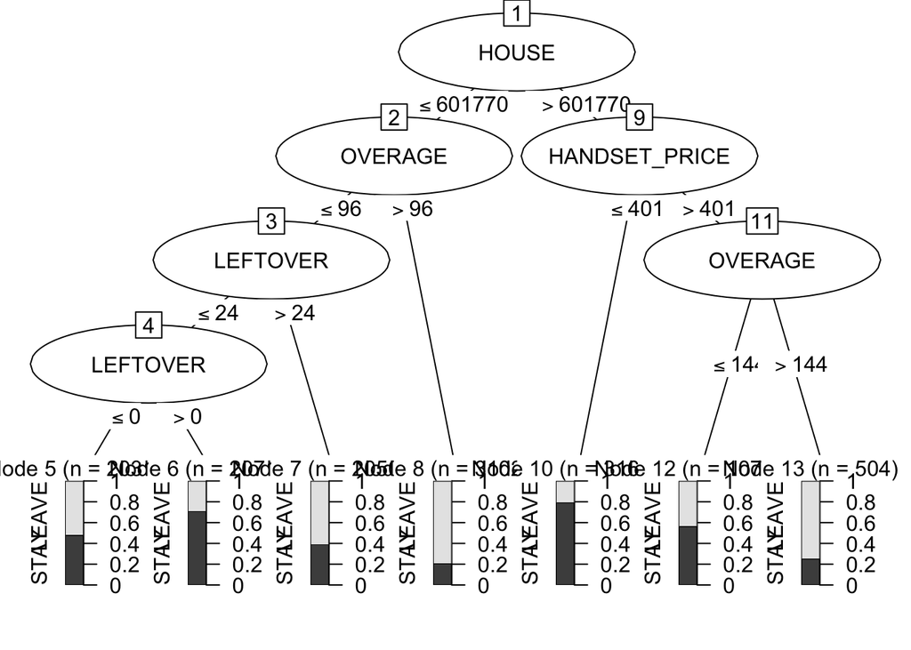

```r
plot(model_4)
```

```r
# get predictions for test, train set
predict_4_test <- predict(model_4, test)
predict_4_train <- predict(model_4, train)

# confusion matrix for test, train set
mmetric(test$LEAVE, predict_4_test, metric="CONF")
```

```
## $res
## NULL
##
## $conf
##        pred
## target  LEAVE STAY
##   LEAVE  2238  747
##   STAY   1095 1920
##
## $roc
## NULL
##
## $lift
## NULL
```

```r
mmetric(train$LEAVE, predict_4_train, metric="CONF")
```

```
## $res
## NULL
##
## $conf
##        pred
## target  LEAVE STAY
##   LEAVE  5141 1726
##   STAY   2546 4587
##
## $roc
## NULL
##
## $lift
## NULL
```

```r
# stats for test, train set
mmetric(test$LEAVE, predict_4_test, metric=c("ACC","TPR","PRECISION","F1"))
```

```
##        ACC       TPR1       TPR2 PRECISION1 PRECISION2        F11        F12
##   69.30000   74.97487   63.68159   67.14671   71.99100   70.84520   67.58184
```

```r
mmetric(train$LEAVE, predict_4_train, metric=c("ACC","TPR","PRECISION","F1"))
```

```
##        ACC       TPR1       TPR2 PRECISION1 PRECISION2        F11        F12
##   69.48571   74.86530   64.30674   66.87915   72.65959   70.64724   68.22847
```